# Marketing A/B Test: Ad vs PSA

Raul Suleymanov

2026-10-28

## Introduction

A company ran a marketing A/B test: most users saw an advertisement (group `ad`), while a small control group saw a neutral public service announcement (group `psa`). The goal of this analysis is to find out whether the ad increases the conversion rate, i.e. the share of users who made a purchase.

- **Dataset:** 588,101 users (Kaggle, “Marketing A/B Testing”)
- **Primary metric:** `converted` (yes/no)
- **Hypothesis:** users who saw the ad convert at a higher rate than the control group

## 1. Data loading

```r
library(tidyverse)
library(janitor)

df <- read_csv("marketing_AB.csv") |>
  clean_names() |>
  select(-1) |>
  mutate(test_group = factor(test_group, levels = c("psa", "ad")))

glimpse(df)
```

```
## Rows: 588,101
## Columns: 6
## $ user_id       <dbl> 1069124, 1119715, 1144181, 1435133, 1015700, 1137664, 11…
## $ test_group    <fct> ad, ad, ad, ad, ad, ad, ad, ad, ad, ad, ad, ad, ad, ad, …
## $ converted     <lgl> FALSE, FALSE, FALSE, FALSE, FALSE, FALSE, FALSE, FALSE, …
## $ total_ads     <dbl> 130, 93, 21, 355, 276, 734, 264, 17, 21, 142, 209, 47, 6…
## $ most_ads_day  <chr> "Monday", "Tuesday", "Tuesday", "Tuesday", "Friday", "Sa…
## $ most_ads_hour <dbl> 20, 22, 18, 10, 14, 10, 13, 18, 19, 14, 11, 13, 20, 13, …
```

## 2. Data quality check

First, we check for missing values and duplicate users, and look at the size of each group.

```r
colSums(is.na(df))
```

```
##       user_id    test_group     converted     total_ads  most_ads_day
##             0             0             0             0             0
## most_ads_hour
##             0
```

```r
sum(duplicated(df$user_id))
```

```
## [1] 0
```

```r
df |>
  count(test_group) |>
  mutate(share = n / sum(n))
```

```
## # A tibble: 2 × 3
##   test_group      n  share
##   <fct>       <int>  <dbl>
## 1 psa         23524 0.0400
## 2 ad         564577 0.960
```

There are no missing values and no duplicate users. The groups are very unbalanced (about 96% `ad` vs 4% `psa`). This looks like a deliberate design of the test (a small control group), so a classic 50/50 split check does not apply here. What matters more is whether the two groups are similar to each other.

## 3. Are the groups comparable?

### Number of ads shown

```r
summary(df$total_ads)
```

```
##    Min. 1st Qu.  Median    Mean 3rd Qu.    Max.
##    1.00    4.00   13.00   24.82   27.00 2065.00
```

```r
quantile(df$total_ads, c(0.5, 0.9, 0.99, 0.999))
```

```
##   50%   90%   99% 99.9%
##  13.0  57.0 202.0 499.9
```

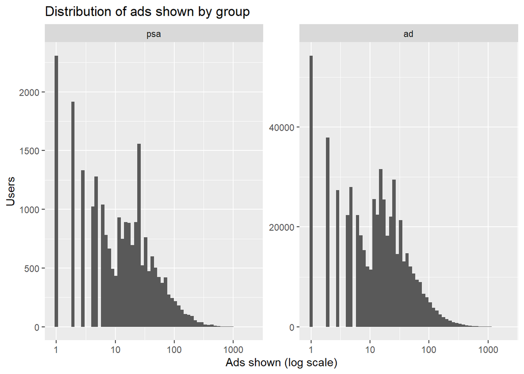

```r
ggplot(df, aes(total_ads)) +
  geom_histogram(bins = 60) +
  scale_x_log10() +
  facet_wrap(~ test_group, scales = "free_y") +
  labs(title = "Distribution of ads shown by group",
       x = "Ads shown (log scale)",
       y = "Users")
```

```r
df |>
  group_by(test_group) |>
  summarise(mean = mean(total_ads),
            median = median(total_ads),
            p90 = quantile(total_ads, 0.9))
```

```
## # A tibble: 2 × 4
##   test_group  mean median   p90
##   <fct>      <dbl>  <dbl> <dbl>
## 1 psa         24.8     12    59
## 2 ad          24.8     13    56
```

```r
wilcox.test(total_ads ~ test_group, data = df)
```

```
##
##  Wilcoxon rank sum test with continuity correction
##
## data:  total_ads by test_group
## W = 6472821126, p-value = 4.691e-11
## alternative hypothesis: true location shift is not equal to 0
```

The mean number of ads is almost identical in both groups (about 25), and the medians are 13 vs 12. The Wilcoxon test is statistically significant only because the sample is huge; the practical difference is negligible.

### Day of the week and hour of the day

```r
tab_day  <- table(df$test_group, df$most_ads_day)
tab_hour <- table(df$test_group, df$most_ads_hour)

round(prop.table(tab_day, 1), 3)
```

```
##
##       Friday Monday Saturday Sunday Thursday Tuesday Wednesday
##   psa  0.162  0.149    0.121  0.130    0.166   0.124     0.148
##   ad   0.157  0.148    0.140  0.146    0.140   0.132     0.137
```

```r
chisq.test(tab_day)
```

```
##
##  Pearson's Chi-squared test
##
## data:  tab_day
## X-squared = 235.61, df = 6, p-value < 2.2e-16
```

```r
chisq.test(tab_hour)
```

```
##
##  Pearson's Chi-squared test
##
## data:  tab_hour
## X-squared = 192.29, df = 23, p-value < 2.2e-16
```

```r
# Effect size (Cramer's V)
cramers_v <- function(tab) {
  chi <- suppressWarnings(chisq.test(tab))$statistic
  unname(sqrt(chi / (sum(tab) * (min(dim(tab)) - 1))))
}

cramers_v(tab_day)
```

```
## [1] 0.02001589
```

```r
cramers_v(tab_hour)
```

```
## [1] 0.01808233
```

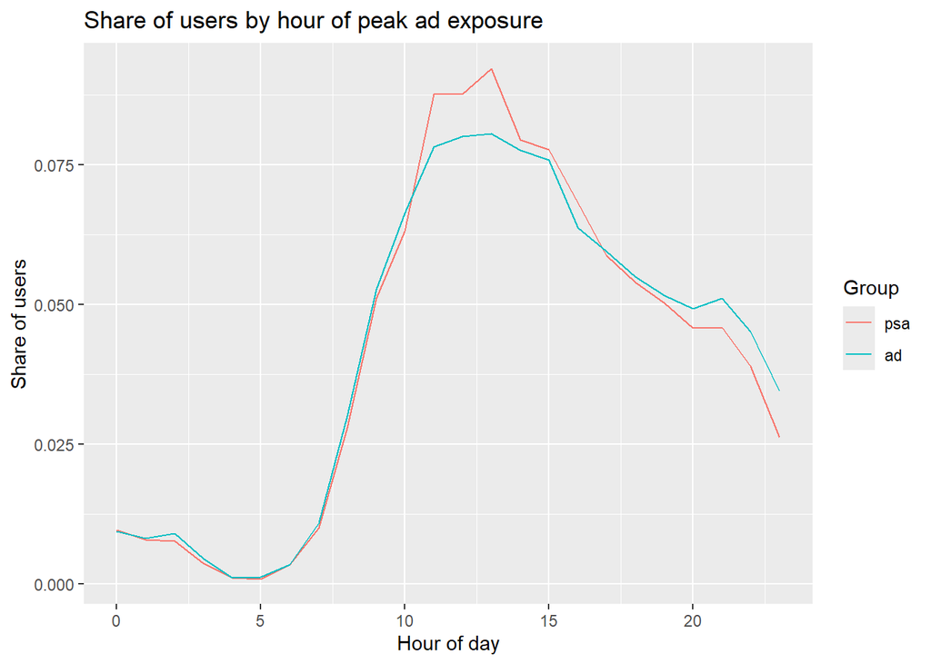

```r
df |>
  count(test_group, most_ads_hour) |>
  group_by(test_group) |>
  mutate(share = n / sum(n)) |>
  ggplot(aes(most_ads_hour, share, color = test_group)) +
  geom_line() +
  labs(title = "Share of users by hour of peak ad exposure",
       x = "Hour of day",
       y = "Share of users",
       color = "Group")
```

Both chi-squared tests give very small p-values, but this is expected with more than half a million users. The effect size (Cramer’s V) is about 0.02 for both day and hour, which is practically zero. The groups are comparable, so a difference in conversion can reasonably be linked to the ad.

## 4. Conversion: ad vs control

```r
conv <- df |>
  group_by(test_group) |>
  summarise(users = n(),
            conversions = sum(converted),
            rate = conversions / users)
conv
```

```
## # A tibble: 2 × 4
##   test_group  users conversions   rate
##   <fct>       <int>       <int>  <dbl>
## 1 psa         23524         420 0.0179
## 2 ad         564577       14423 0.0255
```

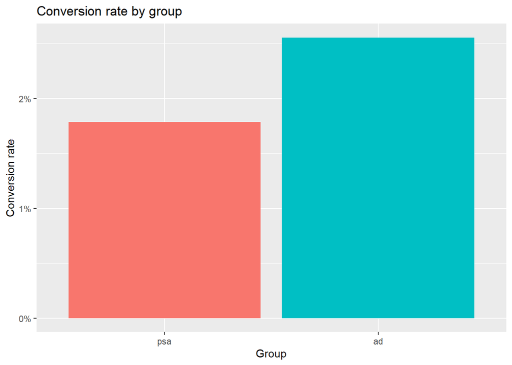

```r
ggplot(conv, aes(test_group, rate, fill = test_group)) +
  geom_col(show.legend = FALSE) +
  scale_y_continuous(labels = scales::percent) +
  labs(title = "Conversion rate by group",
       x = "Group",
       y = "Conversion rate")
```

### Statistical test

We compare two proportions with a two-sample test of proportions.

```r
ad  <- filter(conv, test_group == "ad")
psa <- filter(conv, test_group == "psa")

res <- prop.test(x = c(ad$conversions, psa$conversions),
                 n = c(ad$users, psa$users))
res
```

```
##
##  2-sample test for equality of proportions with continuity correction
##
## data:  c(ad$conversions, psa$conversions) out of c(ad$users, psa$users)
## X-squared = 54.006, df = 1, p-value = 1.999e-13
## alternative hypothesis: two.sided
## 95 percent confidence interval:
##  0.005928792 0.009456114
## sample estimates:
##     prop 1     prop 2
## 0.02554656 0.01785411
```

```r
diff_abs <- ad$rate - psa$rate   # absolute difference
lift_rel <- ad$rate / psa$rate - 1   # relative lift

diff_abs
```

```
## [1] 0.007692453
```

```r
lift_rel
```

```
## [1] 0.4308506
```

```r
res$conf.int   # 95% confidence interval for the difference
```

```
## [1] 0.005928792 0.009456114
## attr(,"conf.level")
## [1] 0.95
```

## Conclusion

**Limitations**

- The control group is small (about 4% of users), so its conversion estimate is less precise. This is reflected in the width of the confidence interval.
- We do not know how users were assigned to groups, so we assume the assignment was random.
- Differences by day, hour or number of ads shown describe associations, not causes, because users did not choose these randomly.
- The analysis does not include the cost of the ads, so we cannot say whether the extra conversions are profitable.